# modeling3: Flexible models for regression (quantitative outcome)

Sebastian Sauer

2016-11-30 16:30:56

# 1 Setup

Setup knitr.

```r
opts_knit$set(root.dir=normalizePath('../'))


knitr::opts_chunk$set(echo = TRUE,
                      cache = TRUE,
                      warning = FALSE,
                      message = FALSE)
```

Load packages, define overhead.

Play or work (test it and recompute vs. rely on cached data)

```r
recompute <- TRUE
test_it <- FALSE
```

```r
source("analysis/functions/paths.R")
```

```r
source("~/Documents/Literatur/Methoden_Literatur/R/R-functions/is_binary.R")
source("~/Documents/Literatur/Methoden_Literatur/R/R-functions/modelfit.R")
```

```r
data_regr <- read_csv("raw_data/data_mod3.csv")



# change strange factor levels to well-behaved ones
if ("contact" %in% names(data_regr)) data_regr$contact <- dplyr::recode_factor(data_regr$contact, `Self-referral` = "0", `CAMHS referral` = "1")


data_regr$responder_3m_f <- factor(data_regr$responder_3m_f, labels = c("negative", "positive"))




data_regr %>%
  mutate_if(is_binary, factor) -> data_regr


if ("ID" %in% names(data_regr)) data_regr <- data_regr %>% dplyr::select(-ID)  # exclude ID




load(file = "data_objects/mod_results.Rda")
```

The dimensions of the data set is 61, 46 (rows/cols).

```r
source("analysis/functions/save_model_results.R")
```

# 2 Upfront work

Before I forget: we need to exclude the categorial outcome variable `responder_3m_f`.

```r
if ("responder_3m_f" %in% names(data_regr)) {
  dplyr::select(data_regr, - responder_3m_f) -> data_regr
  message("responder_3m_f has been excluded from data set.")
} else message("responder_3m_f was *not* present in data set.")
```

## 2.1 CYBOCS_3m

Before starting modelling, it is instructive to visualize (again) the outcome variable (numeric). This is particularly true if the outcome variable is some kind of “plastic” (latent/ constructed) variable that lacks a direct connection to physical-biological kinds as it is often the case for questionnaire data.

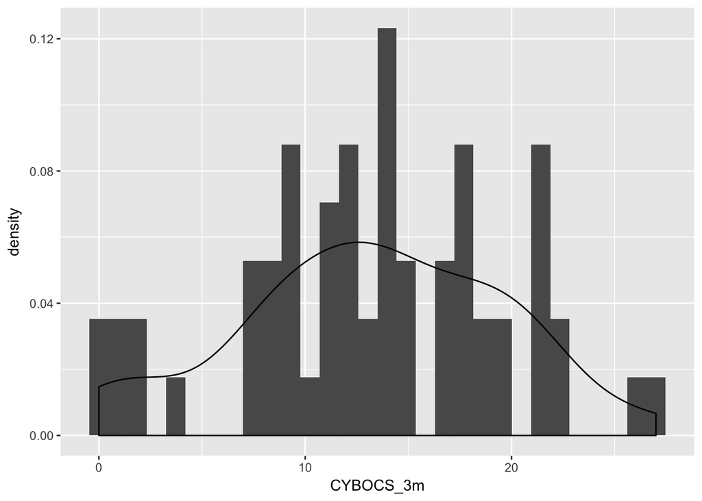

```r
ggplot(data_regr, aes(x = CYBOCS_3m)) + geom_histogram(aes(y = ..density..), bins = 30) + geom_density()
```

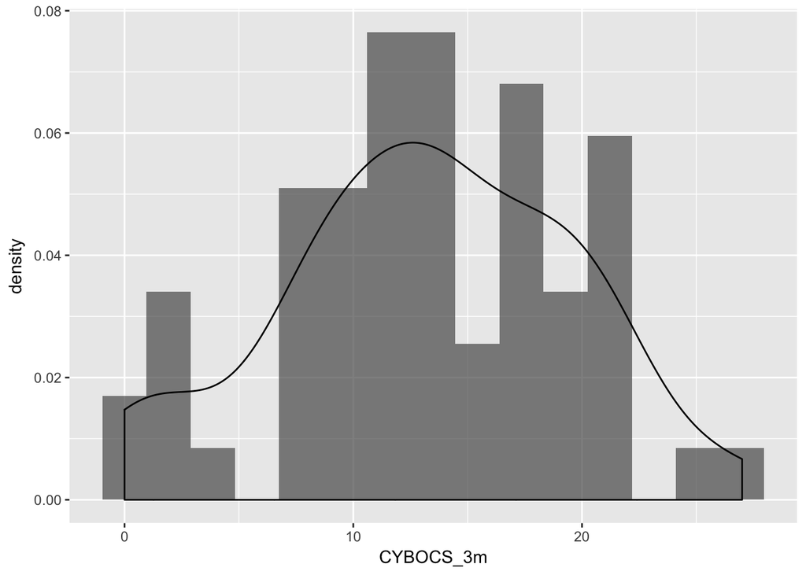

```r
ggplot(data_regr, aes(x = CYBOCS_3m)) + geom_histogram(aes(y = ..density..), bins = 15, alpha = .7) + geom_density()
```

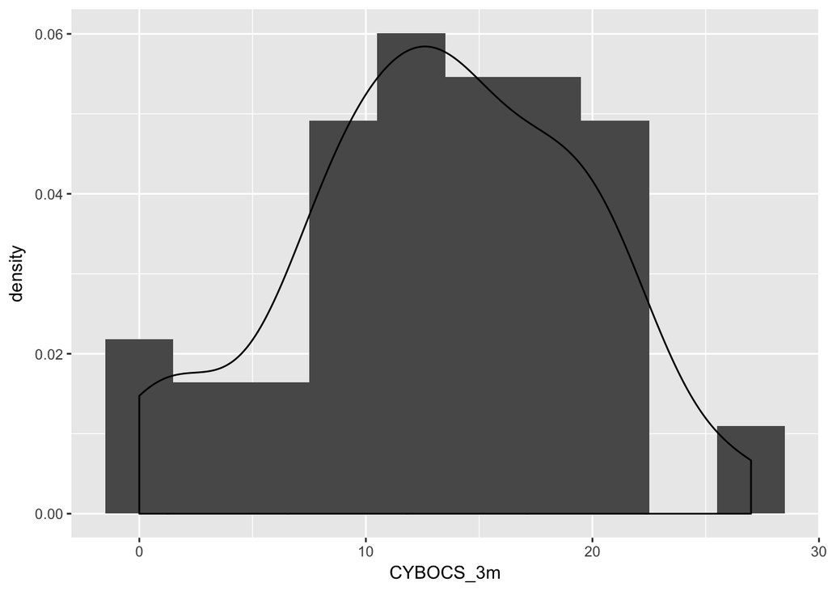

```r
ggplot(data_regr, aes(x = CYBOCS_3m)) + geom_histogram(aes(y = ..density..), bins = 10) + geom_density()
```

Summary statistics:

```r
summary(data_regr$CYBOCS_3m) %>% tidy %>% kable
```

| minimum | q1 | median | mean | q3 | maximum |
| --- | --- | --- | --- | --- | --- |
| 0 | 9 | 14 | 13.18 | 18 | 27 |

## 2.2 Assocation of predictors with numeric outcome variable `CYBOCS_3m`

Now let’s look at something similar: The association of the (numeric) predictors with the numeric outcome variable

```r
data_regr %>%
select_if(is.numeric) %>%
correlate %>%
focus(CYBOCS_3m) %>%
arrange(desc(abs(CYBOCS_3m))) %>% print(n=32)
```

```
## # A tibble: 20 × 2
##                 rowname   CYBOCS_3m
##                   <chr>       <dbl>
## 1          yearswithOCD  0.44929552
## 2             CGI_S_pre  0.41560787
## 3  ChOCI_R_P_sumimp_PRE  0.36392393
## 4        EWSASP_sum_PRE  0.36217135
## 5              OCDonset -0.35556316
## 6      SCAS_S_P_sum_PRE  0.34823758
## 7  ChOCI_R_C_sumimp_PRE  0.27899222
## 8        FAS_PR_sum_PRE  0.27567231
## 9         CDI_S_sum_PRE  0.27456259
## 10       EWSASC_sum_PRE  0.26363139
## 11      CYBOCS_pre_COMP  0.24540779
## 12 ChOCI_R_P_sumsym_PRE  0.21778355
## 13     CYBOCS_pre_avoid  0.20620061
## 14                  age  0.17116217
## 15       CYBOCS_pre_OBS  0.10257745
## 16 ChOCI_R_C_sumsym_PRE  0.09217066
## 17     SCAS_S_C_sum_PRE  0.07943745
## 18        numberdiagnos  0.07381666
## 19   CYBOCS_pre_insight  0.06902211
## 20             distance  0.01909341
```

Hey, that looks quite promising!

Let’s finally plot it:

```
## # A tibble: 20 × 2
##                 rowname   CYBOCS_3m
##                   <chr>       <dbl>
## 1          yearswithOCD  0.44929552
## 2             CGI_S_pre  0.41560787
## 3  ChOCI_R_P_sumimp_PRE  0.36392393
## 4        EWSASP_sum_PRE  0.36217135
## 5              OCDonset -0.35556316
## 6      SCAS_S_P_sum_PRE  0.34823758
## 7  ChOCI_R_C_sumimp_PRE  0.27899222
## 8        FAS_PR_sum_PRE  0.27567231
## 9         CDI_S_sum_PRE  0.27456259
## 10       EWSASC_sum_PRE  0.26363139
## 11      CYBOCS_pre_COMP  0.24540779
## 12 ChOCI_R_P_sumsym_PRE  0.21778355
## 13     CYBOCS_pre_avoid  0.20620061
## 14                  age  0.17116217
## 15       CYBOCS_pre_OBS  0.10257745
## 16 ChOCI_R_C_sumsym_PRE  0.09217066
## 17     SCAS_S_C_sum_PRE  0.07943745
## 18        numberdiagnos  0.07381666
## 19   CYBOCS_pre_insight  0.06902211
## 20             distance  0.01909341
```

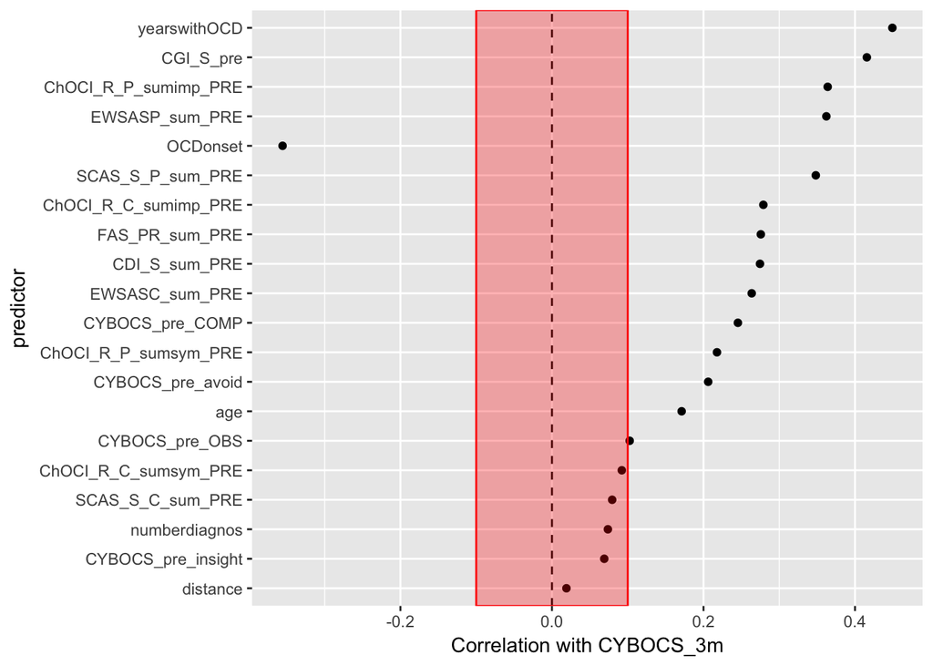

```r
data_rect <- data.frame(xmin = -Inf, xmax = Inf, ymin = -.1, ymax = .1)


data_regr %>%
  select_if(is.numeric) %>%
  correlate  %>%
  focus(CYBOCS_3m) %>%
  arrange(desc(abs(CYBOCS_3m))) %>% print(n=32) %>%
  ggplot(aes(x = reorder(rowname, abs(CYBOCS_3m)), y = CYBOCS_3m)) + geom_point() +
  coord_flip() +
  xlab("predictor") +
  ylab("Correlation with CYBOCS_3m") +
  # ggtitle("Correlations of predictors with outcome (CYBOCS_3m)") +
  geom_hline(yintercept = 0, linetype = "dashed")  +
  geom_rect(data = data_rect,
            aes(ymin = ymin, ymax = ymax, xmin = xmin, xmax = xmax), inherit.aes = FALSE, alpha = .3, fill = "red", color = "red")
```

## 2.3 split in train vs. test sample

```r
set.seed(42)
trainIndex <- createDataPartition(data_regr$CYBOCS_3m, p = .8,
                                  list = FALSE,
                                  times = 1)

train_sample <- data_regr[trainIndex, ]
test_sample <- data_regr[-trainIndex, ]



predictor_names <- names(train_sample)[names(train_sample) != "CYBOCS_3m"]
outcome_name <- "CYBOCS_3m"
```

# 3 Models

For each model, the model performance reported is always based on the **test** sample (not the *training* sample), unless noted otherwise.

## 3.1 Lasso 80/20

```r
do_lasso <- function(data = data_regr, p = .8, save = FALSE){


  data_mm <- model.matrix(CYBOCS_3m ~ ., data = data)

  data_mm <- data_mm[, -1]  #exclude intercept as glmnet demeans the data and reports intercept by default: http://stats.stackexchange.com/questions/99546/2-intercept-cooficients-in-glmnet-output

  set.seed(42)
  trainIndex <- createDataPartition(data$CYBOCS_3m, p = p,
                                    list = FALSE,
                                    times = 1)

  train_mm <- data_mm[trainIndex, ]
  test_mm <- data_mm[-trainIndex, ]

  train_sample <- data_regr[trainIndex, ]
  test_sample <- data_regr[-trainIndex, ]


  message("Do LASSO\n")
  lasso_cv <- glmnet::cv.glmnet(y = train_sample$CYBOCS_3m,
                                x = train_mm,
                                family = "gaussian",
                                alpha = 1)  # lasso penalty

  results_lasso <- list()

  results_lasso$model <- lasso_cv

  summary(lasso_cv)
  print(lasso_cv)
  plot(lasso_cv)

  coef_lasso <- coef(lasso_cv, s = "lambda.min")
  coef_lasso

  results_lasso$coefs <- coef_lasso

  coef_lasso_num <- as.numeric(coef_lasso)
  index_coefs_not_zero <- which(coef_lasso_num != 0)
  names_not_zero <- coef_lasso@Dimnames[[1]][index_coefs_not_zero]
  values_not_zero <- coef_lasso_num[coef_lasso_num != 0]

  lasso_coefs_not_zero <- tibble(
    name = names_not_zero,
    value = values_not_zero
  )

  lasso_coefs_not_zero %>%
    filter(name != "(Intercept)") -> lasso_coefs_not_zero


  results_lasso$lasso_coefs_not_zero <- lasso_coefs_not_zero

  ggplot(lasso_coefs_not_zero, aes(x = name, y = value)) +
    geom_point() +
    coord_flip() +
    ggtitle("Non-zero regression values for Lasso GLM net 80/20 sample") -> p1

  p1

  lasso_pred <- predict(lasso_cv, test_mm, s = "lambda.min", type = "response")
  lasso_pred <- as.numeric(lasso_pred)

  results_lasso$lasso_pred <- lasso_pred

  pred_obs <- tibble(
    pred = as.numeric(lasso_pred),
    obs = as.numeric(test_sample$CYBOCS_3m)
  )

  ggplot(pred_obs, aes(x = obs, y = pred)) +
    geom_abline(slope = 1, intercept = 0, linetype = "dashed") +
    geom_point() +
    xlim(c(0,20)) +
    ylim(c(0,20)) +
    ggtitle("Test sample (real) values vs. predicted values") -> p2

  p2





  cat(paste("R squared is:", round(R_2(pred_obs$pred, pred_obs$obs), 2), "\n"))

  results_lasso$R_2 <- R_2(pred = pred_obs$pred, obs = pred_obs$obs)

  cat(paste("RMSE is:", round(RMSE(pred = pred_obs$pred, obs = pred_obs$obs), 2), "\n"))

  results_lasso$RMSE <- RMSE(pred = pred_obs$pred, obs = pred_obs$obs)

  cat(paste("Mean absolute error is:", round(mean(abs(pred_obs$pred - pred_obs$obs)), 2), "\n"))

  results_lasso$mean_abs_error <- mean(abs(pred_obs$pred - pred_obs$obs))

  if (save == TRUE) {
    mod_results$lasso_reg_1 <- save_model_results(obj = lasso_cv,
                                                  test_df = test_mm,
                                                  predict_results = FALSE,
                                                  report_varimp = FALSE,
                                                  fit_pred = lasso_pred,
                                                  conf_matrix = "none")
  }


  results_lasso$plots[[1]] <- p1
  results_lasso$plots[[2]] <- p2

  return(results_lasso)
} # End of function "do lasso"
```

```r
# undebug(do_lasso)
# debug(do_lasso)
lasso_regr_1 <- do_lasso()
```

```
## $lambda
##  [1] 3.147684498 2.868052882 2.613262969 2.381107889 2.169576827
##  [6] 1.976837601 1.801220797 1.641205306 1.495405150 1.362557478
## [11] 1.241511627 1.131219156 1.030724764 0.939158016 0.855725807
## [16] 0.779705484 0.710438598 0.647325191 0.589818605 0.537420746
## [21] 0.489677768 0.446176145 0.406539086 0.370423274 0.337515891
## [26] 0.307531910 0.280211622 0.255318394 0.232636612 0.211969816
## [31] 0.193139002 0.175981065 0.160347393 0.146102572 0.133123222
## [36] 0.121296922 0.110521238 0.100702836 0.091756673 0.083605263
## [41] 0.076178002 0.069410558 0.063244316 0.057625865 0.052506542
## [46] 0.047842006 0.043591854 0.039719273 0.036190723 0.032975639
## [51] 0.030046174 0.027376955 0.024944861 0.022728829 0.020709662
## [56] 0.018869873 0.017193525 0.015666100 0.014274367 0.013006271
## [61] 0.011850830 0.010798035 0.009838767 0.008964718 0.008168317
## [66] 0.007442667 0.006781481 0.006179033 0.005630104 0.005129941
```

[output cut: 196 more lines]

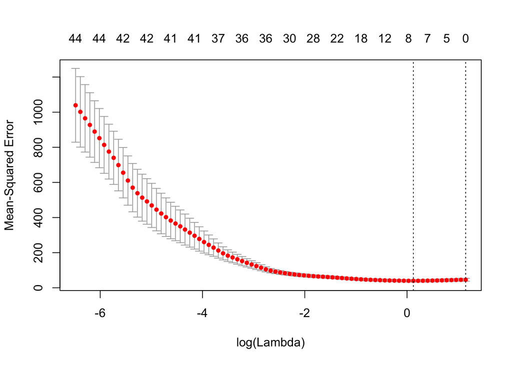

```
## R squared is: 0.15
## RMSE is: 4.99
## Mean absolute error is: 4.33
```

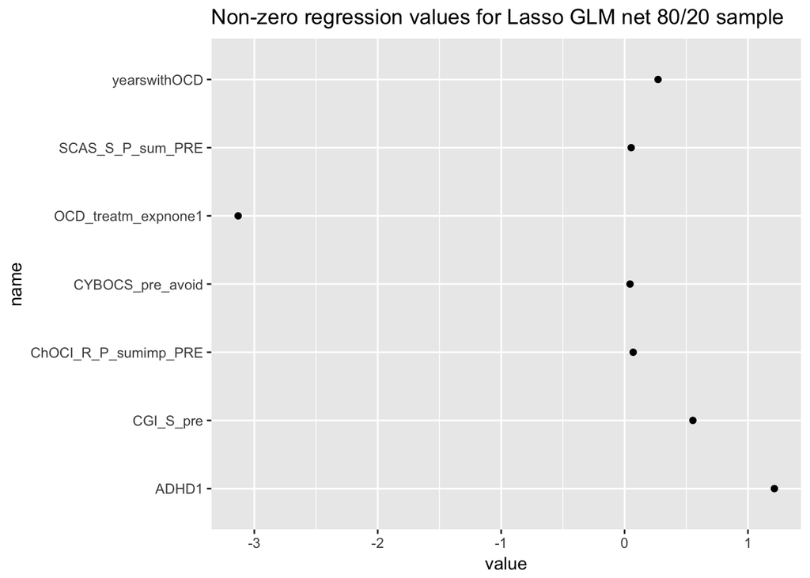

```r
lasso_regr_1$plots[[1]]
```

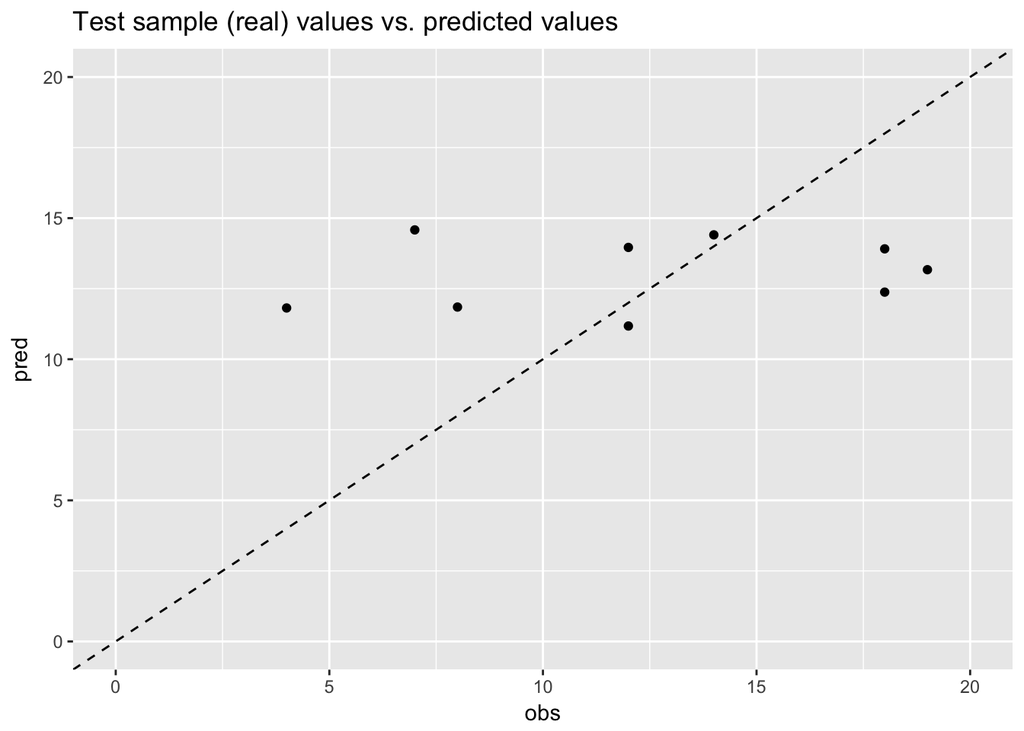

```r
lasso_regr_1$plots[[2]]
```

The exact (non-zero) beta coefficients are:

```r
lasso_regr_1$lasso_coefs_not_zero %>% kable
```

| name | value |
| --- | --- |
| CYBOCS_pre_avoid | 0.0442560 |
| ChOCI_R_P_sumimp_PRE | 0.0698248 |
| SCAS_S_P_sum_PRE | 0.0536191 |
| ADHD1 | 1.2139393 |
| yearswithOCD | 0.2711508 |
| OCD_treatm_expnone1 | -3.1310571 |
| CGI_S_pre | 0.5534702 |

Let’s look at the varimp:

```r
lasso_regr_1$lasso_coefs_not_zero %>%
  mutate(rank = min_rank(desc(value))) -> regr_varimp$lasso_regr_1

regr_varimp$lasso_regr_1 %>% kable
```

| name | value | rank |
| --- | --- | --- |
| CYBOCS_pre_avoid | 0.0442560 | 6 |
| ChOCI_R_P_sumimp_PRE | 0.0698248 | 4 |
| SCAS_S_P_sum_PRE | 0.0536191 | 5 |
| ADHD1 | 1.2139393 | 1 |
| yearswithOCD | 0.2711508 | 3 |
| OCD_treatm_expnone1 | -3.1310571 | 7 |
| CGI_S_pre | 0.5534702 | 2 |

## 3.2 Lasso 60/40

Let’s compute the Lasso again but increase the test sample. 20% test sample amounted to 10 observations only. One could speculate that is is too few for numeric stability. Here comes a 60/40 sample split (all other remaining equal).

```r
lasso_regr_2 <- do_lasso(p = .6)
```

```
## $lambda
##  [1] 3.60145026 3.43775878 3.28150734 3.13235777 2.98998727 2.85408774
##  [7] 2.72436504 2.60053845 2.48233996 2.36951378 2.26181572 2.15901271
## [13] 2.06088225 1.96721197 1.87779915 1.79245028 1.71098065 1.63321394
## [19] 1.55898184 1.48812371 1.42048619 1.35592290 1.29429411 1.23546645
## [25] 1.17931259 1.12571101 1.07454571 1.02570595 0.97908603 0.93458506
## [31] 0.89210673 0.85155910 0.81285442 0.77590894 0.74064268 0.70697932
## [37] 0.67484602 0.64417323 0.61489456 0.58694666 0.56026902 0.53480393
## [43] 0.51049627 0.48729343 0.46514519 0.44400362 0.42382297 0.40455956
## [49] 0.38617171 0.36861961 0.35186528 0.33587246 0.32060653 0.30603447
## [55] 0.29212473 0.27884721 0.26617318 0.25407520 0.24252709 0.23150386
## [61] 0.22098165 0.21093769 0.20135025 0.19219857 0.18346285 0.17512418
## [67] 0.16716451 0.15956663 0.15231408 0.14539117 0.13878292 0.13247502
## [73] 0.12645382 0.12070630 0.11522001 0.10998309 0.10498419 0.10021249
## [79] 0.09565768 0.09130989 0.08715972 0.08319817 0.07941669 0.07580708
```

[output cut: 200 more lines]

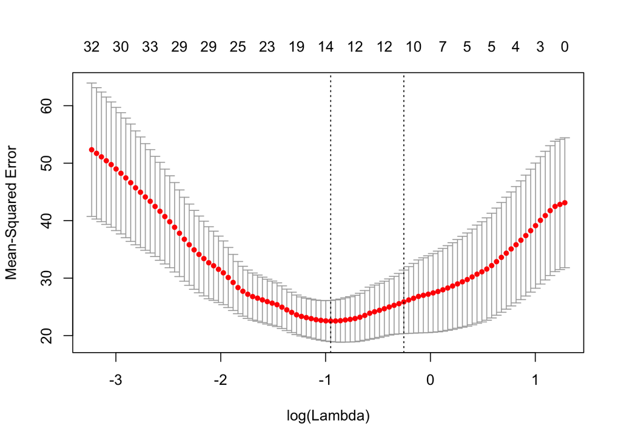

```
## R squared is: -0.81
## RMSE is: 8.36
## Mean absolute error is: 6.72
```

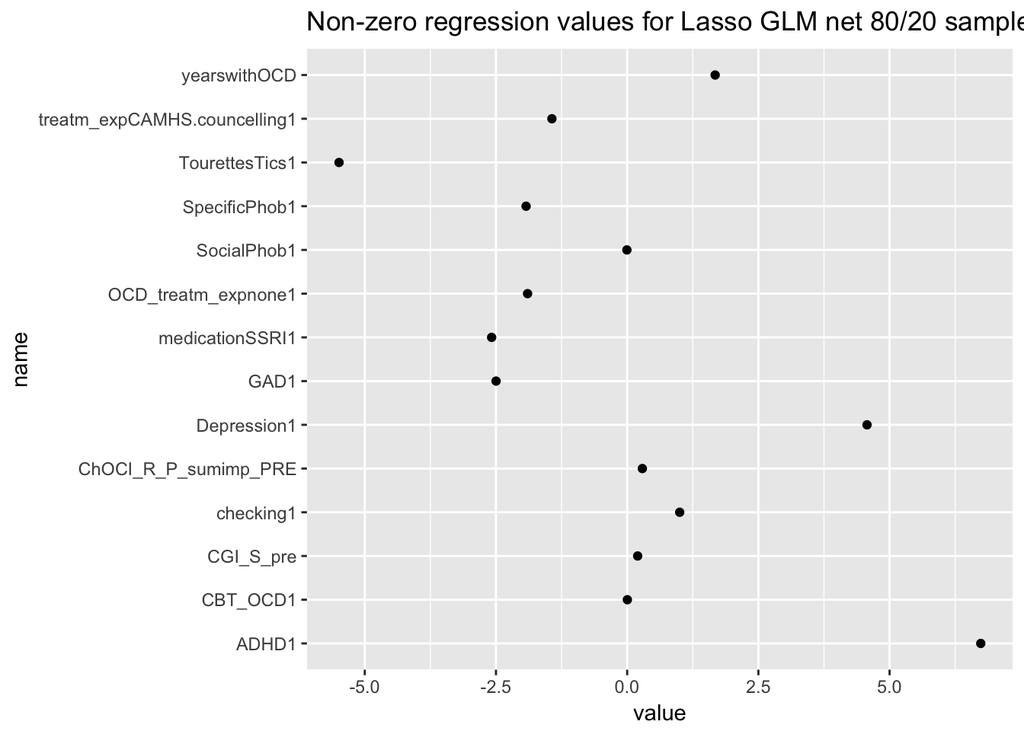

```r
lasso_regr_2$plots[[1]]
```

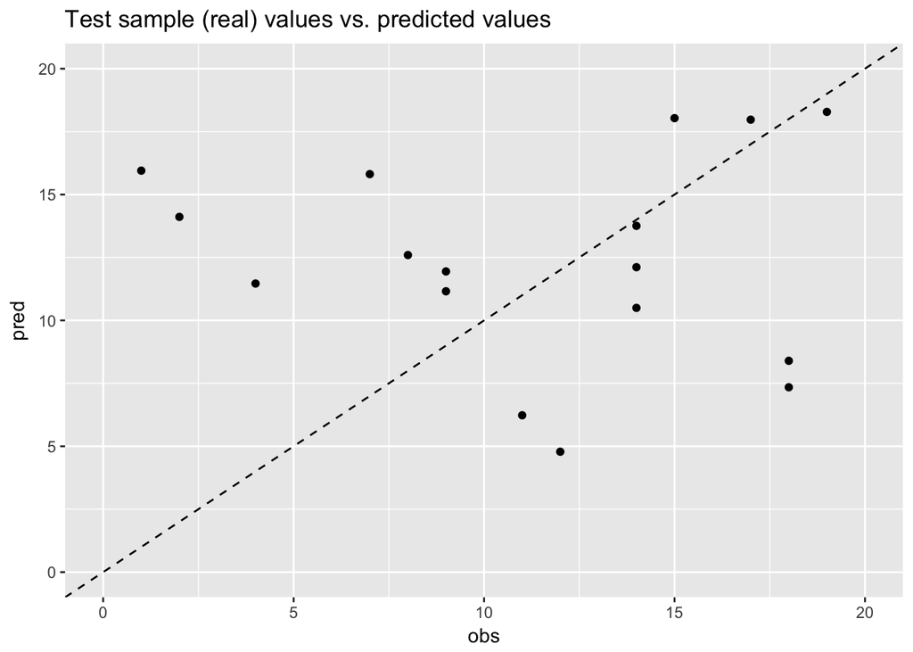

```r
lasso_regr_2$plots[[2]]
```

Varimp:

```r
lasso_regr_2$lasso_coefs_not_zero %>%
  mutate(rank = min_rank(desc(value))) -> regr_varimp$lasso_regr_2
```

## 3.3 Random Forest

```r
  data_mm <- model.matrix(CYBOCS_3m ~ ., data = data_regr)

  data_mm <- data_mm[, -1]  #exclude intercept as glmnet demeans the data and reports intercept by default: http://stats.stackexchange.com/questions/99546/2-intercept-cooficients-in-glmnet-output

  set.seed(42)
  trainIndex <- createDataPartition(data_regr$CYBOCS_3m, p = .8,
                                    list = FALSE,
                                    times = 1)

  train_mm <- data_mm[trainIndex, ]
  test_mm <- data_mm[-trainIndex, ]
  train_sample <- data_regr[trainIndex, ]
  test_sample <- data_regr[-trainIndex, ]
```

```r
control <- trainControl(method="repeatedcv", number=10, repeats=3, search="random")

set.seed(42)
rf_regr_1 <- train(x = train_mm,
                   y = train_sample$CYBOCS_3m,
                   method = "rf",
                   importance = TRUE,
                   tuneLength=15,
                   trControl=control,
                   ntrees = 1000)
```

Let’s look at the importance of the variables; the results come from the train sample. But note that RF always predict on the hold-out-sample (test sample). However, we used the number of trees for tuning (`mtry`). That’s why we better also look at the performance of the test sample (later).

```r
rf1_varimp <- varImp(rf_regr_1, scale=FALSE)
print(rf1_varimp)
```

```
## rf variable importance
##
##   only 20 most important variables shown (out of 44)
##
##                               Overall
## yearswithOCD                  8.47664
## EWSASP_sum_PRE                6.37728
## CDI_S_sum_PRE                 5.35847
## OCD_treatm_expnone1           5.32118
## OCDonset                      3.83753
## CBT_OCD1                      2.93194
## CYBOCS_pre_COMP               2.67256
## CGI_S_pre                     2.53424
## sexgirl1                      2.42373
## EWSASC_sum_PRE                2.40981
## ChOCI_R_P_sumimp_PRE          1.55676
## CYBOCS_pre_OBS                1.55090
## treatm_expnone1               1.13391
## age                           1.11422
## ADHD1                         1.03981
## treatm_expCAMHS.councelling1  0.99418
## SocialPhob1                   0.98576
## symmetry1                     0.85248
## Education_parentOther1        0.74189
## Education_parentHigh.school1 -0.06755
```

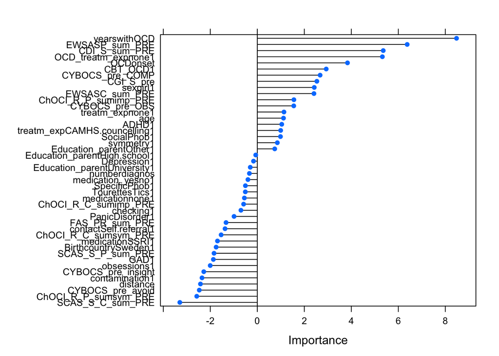

```r
plot(rf1_varimp)
```

```r
rf1_varimp$importance %>%
  rownames_to_column %>%
  dplyr::rename(name = rowname, value = Overall) %>%
  mutate(rank = min_rank(desc(value))) -> regr_varimp$rf_1
```

Note that the mean decrease in accuracy is depicted, ie., the MSE if the respective variable would be randomly permutated. [Source](http://topepo.github.io/caret/variable-importance.html)

Ok, and now we predict the values of the test sample.

```r
rf1_predict <- predict(rf_regr_1, newdata = test_mm)
rf1_predict
```

```
##        3        5       21       32       37       40       43       46
## 13.51673  9.27900 13.24063 12.55560 15.24220 13.63260 13.60883 15.04597
##       58       61
## 15.77297 11.15800
```

```r
rf1_RMSE_test <- sqrt(mean((rf1_predict - test_sample$CYBOCS_3m)^2))
rf1_R_2_test <- R_2(rf1_predict, test_sample$CYBOCS_3m)
```

RMSE amounts to 4.8165153; $R^2$ to 0.2111928.

## 3.4 SVM

Let’s look at Support Vector Machines (SVM) with radial kernel.

```r
control <- trainControl(method="repeatedcv", number=10, repeats=3, search="random")

set.seed(42)
svm_regr_1 <- train(x = train_mm,
                   y = train_sample$CYBOCS_3m,
                   method = "svmRadial",
                   importance = TRUE,
                   tuneLength=15,
                   preProc = c("center", "scale"),
                   trControl = control,
                   savePred = T)
```

Here are the model results of the training process (15 tuning steps), sorted by R squared:

```r
svm_regr_1$results %>%
  arrange(desc(Rsquared))
```

```
##          sigma            C     RMSE  Rsquared   RMSESD RsquaredSD
## 1  0.004542892   0.11261795 6.237647 0.3467724 1.568783  0.2994191
## 2  0.039698543   5.65833026 6.116637 0.3427315 1.696175  0.3246471
## 3  0.004419886   0.79319324 5.987467 0.3300832 1.546858  0.2901213
## 4  0.006168941   0.26347613 6.126763 0.3215244 1.572192  0.2833705
## 5  0.007378529   0.12749013 6.223350 0.3209278 1.578409  0.2904664
## 6  0.009397382   0.03905777 6.312830 0.3200471 1.589227  0.2981616
## 7  0.013414517  19.48474579 6.686301 0.3035561 1.892320  0.2926901
## 8  0.012729861 469.73014272 6.733395 0.3025956 1.898043  0.2918163
## 9  0.011665192 582.48917928 6.814369 0.3011514 1.906526  0.2903193
## 10 0.011118618  52.81242208 6.860566 0.3005718 1.912022  0.2896564
## 11 0.005247027  11.86391665 7.566979 0.2931690 1.944134  0.2683942
## 12 0.004923147 262.99057880 7.715592 0.2928399 2.061602  0.2764910
## 13 0.003520849 126.36075152 8.108187 0.2899403 2.134983  0.2693781
## 14 0.013861765   0.09841531 6.274684 0.2862468 1.593661  0.2949784
## 15 0.003551124   8.55622421 7.076558 0.2771984 1.780441  0.2593401
```

```r
svm_regr_1$finalModel
```

```
## Support Vector Machine object of class "ksvm"
##
## SV type: eps-svr  (regression)
##  parameter : epsilon = 0.1  cost C = 0.793193236717649
##
## Gaussian Radial Basis kernel function.
##  Hyperparameter : sigma =  0.00441988620368978
##
## Number of Support Vectors : 46
##
## Objective Function Value : -22.8379
## Training error : 0.592028
```

```r
#str(svm_regr_1$finalModel)
```

The best model in the tuning process was

```r
svm_regr_1$results %>%
  arrange(desc(Rsquared)) %>%
  filter(row_number() == 1)
```

```
##         sigma         C     RMSE  Rsquared   RMSESD RsquaredSD
## 1 0.004542892 0.1126179 6.237647 0.3467724 1.568783  0.2994191
```

```r
svm1_varimp <- varImp(svm_regr_1, scale=FALSE)
str(svm1_varimp)
```

```
## List of 3
##  $ importance:'data.frame':  44 obs. of  1 variable:
##   ..$ Overall: num [1:44] 0.02683 0.07847 0.00462 0.09706 0.09095 ...
##  $ model     : chr "loess r-squared"
##  $ calledFrom: chr "varImp"
##  - attr(*, "class")= chr "varImp.train"
```

```r
# svm1_varimp2 <- filterVarImp(svm_regr_1)
print(svm1_varimp)
```

```
## loess r-squared variable importance
##
##   only 20 most important variables shown (out of 44)
##
##                              Overall
## EWSASP_sum_PRE               0.35790
## ChOCI_R_P_sumimp_PRE         0.29037
## yearswithOCD                 0.28031
## OCD_treatm_expnone1          0.23451
## SCAS_S_P_sum_PRE             0.22324
## CDI_S_sum_PRE                0.20524
## CBT_OCD1                     0.19515
## OCDonset                     0.19178
## CGI_S_pre                    0.17918
## ChOCI_R_C_sumimp_PRE         0.16607
## EWSASC_sum_PRE               0.15417
## CYBOCS_pre_avoid             0.09706
## ADHD1                        0.09580
## ChOCI_R_C_sumsym_PRE         0.09095
## FAS_PR_sum_PRE               0.08170
## CYBOCS_pre_COMP              0.07847
## ChOCI_R_P_sumsym_PRE         0.07254
## medication_yesno1            0.06545
## medicationnone1              0.06545
## Education_parentHigh.school1 0.04439
```

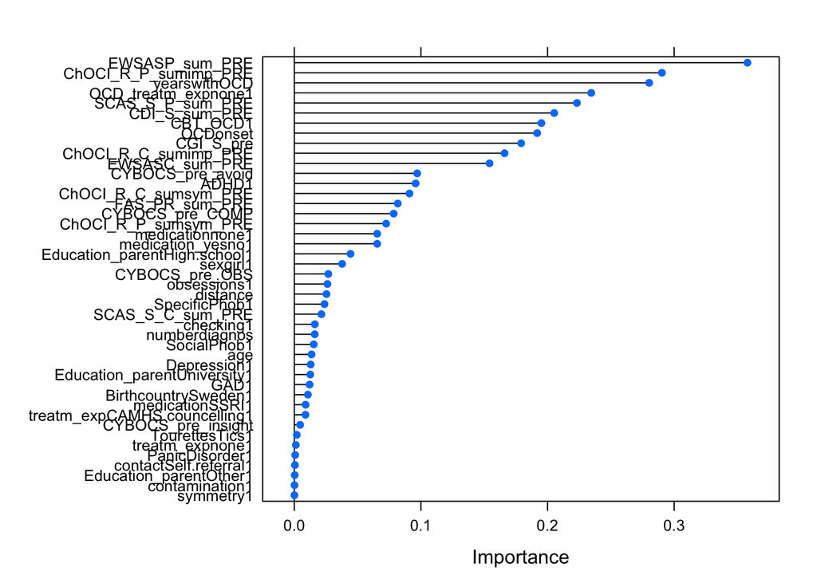

```r
plot(svm1_varimp)
```

```r
svm1_varimp$importance %>%
  rownames_to_column %>%
  dplyr::rename(name = rowname, value = Overall) %>%
  mutate(rank = min_rank(desc(value))) -> regr_varimp$svm_1
```

As SVM does not provide a variable importance statistics, here the $R^2$ statistic is presented (for a linear model with one predictor against the Null model).

Ok, and now we predict the values of the test sample.

```r
svm1_predict <- predict(svm_regr_1, newdata = test_mm)
svm1_RMSE_test <- sqrt(mean((svm1_predict - test_sample$CYBOCS_3m)^2))
svm1_R_2_test <- R_2(svm1_predict, test_sample$CYBOCS_3m)
```

RMSE amounts to 5.2964296; $R^2$ to 0.0461691.

## 3.5 Boosting (Stochastic Gradient Boosting)

In ensemble learning such as Boosting, serveral weak learners are combined to yield a more accurate learning ensemble. A particularity of Boosting is that misclassified cases get more weight, so that they are “more closely looked after” in subsequent runs.

```r
control <- trainControl(method="repeatedcv", number=10, repeats=3)

set.seed(42)
gbm_regr_1 <- train(y = train_sample$CYBOCS_3m,
                    x = train_mm,
                    method = "gbm",
                    # importance = FALSE,
                    tuneLength=10,
                    preProc = c("center", "scale"),
                    trControl=control
                    # n.trees = 1000
                    )
```

Let’s check some results.

```r
gbm_regr_1
```

```
## Stochastic Gradient Boosting
##
## 51 samples
## 44 predictors
##
## Pre-processing: centered (44), scaled (44)
## Resampling: Cross-Validated (10 fold, repeated 3 times)
## Summary of sample sizes: 46, 46, 47, 45, 47, 47, ...
## Resampling results across tuning parameters:
##
##   interaction.depth  n.trees  RMSE      Rsquared
##    1                  50      5.984620  0.3265110
##    1                 100      6.214852  0.3265683
##    1                 150      6.469470  0.3077307
##    1                 200      6.639264  0.3015213
```

[output cut: 103 more lines]

```r
gbm_regr_1$results
```

```
##     shrinkage interaction.depth n.minobsinnode n.trees     RMSE  Rsquared
## 1         0.1                 1             10      50 5.984620 0.3265110
## 11        0.1                 2             10      50 6.023532 0.3221420
## 21        0.1                 3             10      50 5.724442 0.4194194
## 31        0.1                 4             10      50 5.994321 0.3210854
## 41        0.1                 5             10      50 5.976200 0.3540022
## 51        0.1                 6             10      50 6.120084 0.2979728
## 61        0.1                 7             10      50 5.956728 0.3692015
## 71        0.1                 8             10      50 5.915416 0.3625785
## 81        0.1                 9             10      50 5.931793 0.3628705
## 91        0.1                10             10      50 6.065985 0.3170815
## 2         0.1                 1             10     100 6.214852 0.3265683
## 12        0.1                 2             10     100 6.193636 0.3112128
## 22        0.1                 3             10     100 6.184826 0.3458224
## 32        0.1                 4             10     100 6.169788 0.3148799
```

[output cut: 187 more lines]

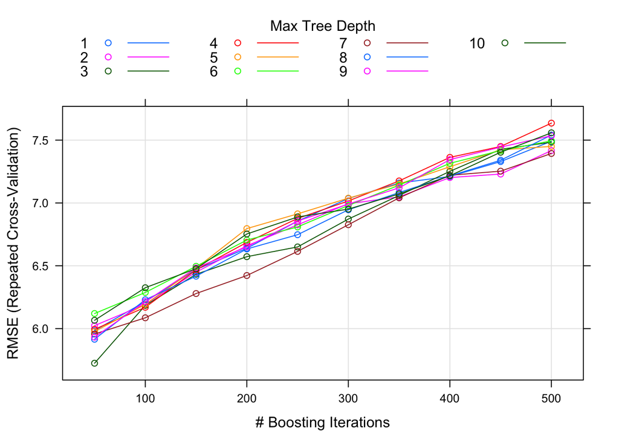

```r
plot(gbm_regr_1)
```

It appears that fewer boosting iterations lead to better RMSE here. Let’s check the best training model:

```r
gbm_regr_1$results %>%
  arrange(desc(Rsquared)) %>%
  filter(row_number() == 1)
```

```
##   shrinkage interaction.depth n.minobsinnode n.trees     RMSE  Rsquared
## 1       0.1                 3             10      50 5.724442 0.4194194
##     RMSESD RsquaredSD
## 1 2.105132  0.2832291
```

Variample importance:

```r
gbm1_varimp <- varImp(gbm_regr_1, scale=FALSE)
print(gbm1_varimp)
```

```
## gbm variable importance
##
##   only 20 most important variables shown (out of 44)
##
##                              Overall
## ChOCI_R_P_sumimp_PRE         1281.21
## yearswithOCD                 1213.21
## OCDonset                      834.64
## CYBOCS_pre_COMP               710.19
## EWSASC_sum_PRE                422.78
## SCAS_S_C_sum_PRE              291.47
## SCAS_S_P_sum_PRE              271.55
## treatm_expnone1               265.31
## CGI_S_pre                     213.22
## CYBOCS_pre_avoid              208.37
## Education_parentUniversity1   201.74
## CYBOCS_pre_OBS                184.85
## treatm_expCAMHS.councelling1  175.66
## sexgirl1                      139.32
## numberdiagnos                  99.35
## CYBOCS_pre_insight             92.83
## checking1                      89.73
## age                            77.27
## obsessions1                    72.43
## distance                       42.31
```

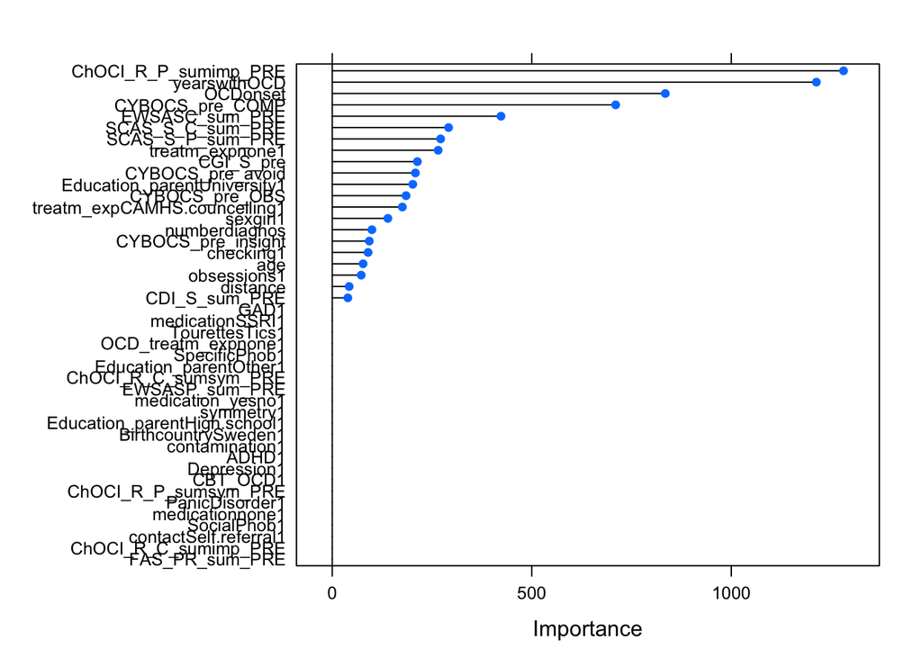

```r
plot(gbm1_varimp)
```

```r
gbm1_varimp$importance %>%
  rownames_to_column %>%
  dplyr::rename(name = rowname, value = Overall) %>%
  mutate(rank = min_rank(desc(value))) -> regr_varimp$gbm_1
```

Ok, and now we predict the values of the test sample.

```r
gbm1_predict <- predict(gbm_regr_1, newdata = test_mm)
gbm1_RMSE_test <- sqrt(mean((gbm1_predict - test_sample$CYBOCS_3m)^2))
gbm1_R_2_test <- R_2(gbm1_predict, test_sample$CYBOCS_3m)
```

RMSE amounts to 5.1122537. Slightly better than the model before. $R^2$ amounts to 0.111352.

## 3.6 Plain regression with univariate feature selection

### 3.6.1 Select features (predictors)

This is an implementation of Fabian’s way to select features: Run a simple regression with one predictor; repeat for each predictor in the data set. Then choose the “most important” predictors based on the R^2’s. Finally run a multiple regression with all “most important” predictors. This procedure basically amounts to looking at (zero-order) correlations of the predictors with the outcome and choosing the predictors having the highest correlation with the outcome. Note that here bivariate assocations only are looked at. No correction is undertaken for “overlapping” correlations.

```r
train_sample %>%
  dplyr::select(-CYBOCS_3m) %>%
  map(~lm(train_sample$CYBOCS_3m ~ .x, data = train_sample)) %>%
  map(summary) %>%
  map_dbl("r.squared") %>%
  tidy %>%
  dplyr::arrange(desc(x)) %>%
  dplyr::rename(r.squared = x) %>%
  kable
```

| names | r.squared |
| --- | --- |
| OCD_treatm_expnone | 0.2345075 |
| CBT_OCD | 0.1951454 |
| EWSASP_sum_PRE | 0.1904354 |
| yearswithOCD | 0.1876247 |
| CGI_S_pre | 0.1791774 |
| ChOCI_R_P_sumimp_PRE | 0.1791586 |
| OCDonset | 0.1460604 |
| SCAS_S_P_sum_PRE | 0.1264097 |
| CYBOCS_pre_avoid | 0.0970586 |
| ADHD | 0.0958044 |
| ChOCI_R_C_sumimp_PRE | 0.0835263 |
| CYBOCS_pre_COMP | 0.0784748 |
| CDI_S_sum_PRE | 0.0763562 |
| EWSASC_sum_PRE | 0.0741768 |
| medication_yesno | 0.0654530 |
| medicationnone | 0.0654530 |
| FAS_PR_sum_PRE | 0.0464815 |
| Education_parentHigh.school | 0.0443871 |
| sexgirl | 0.0377671 |
| ChOCI_R_P_sumsym_PRE | 0.0344701 |
| CYBOCS_pre_OBS | 0.0268310 |
| obsessions | 0.0261652 |
| SpecificPhob | 0.0238248 |
| checking | 0.0162210 |
| numberdiagnos | 0.0161061 |
| SocialPhob | 0.0153561 |
| age | 0.0136233 |
| Depression | 0.0129449 |
| Education_parentUniversity | 0.0126297 |
| GAD | 0.0120884 |
| BirthcountrySweden | 0.0107394 |
| medicationSSRI | 0.0089213 |
| treatm_expCAMHS.councelling | 0.0087878 |
| SCAS_S_C_sum_PRE | 0.0054681 |
| distance | 0.0053005 |
| ChOCI_R_C_sumsym_PRE | 0.0050074 |
| CYBOCS_pre_insight | 0.0046228 |
| TourettesTics | 0.0019798 |
| treatm_expnone | 0.0012138 |
| PanicDisorder | 0.0007087 |
| contactSelf.referral | 0.0005052 |
| Education_parentOther | 0.0003383 |
| contamination | 0.0001588 |
| symmetry | 0.0000963 |

We could also argue that, FWIW, we would want to guide our predictor (feature) selection by significance of p-values. At the least, this gives us simple guidance as to which variables to retain. Let’s see:

```r
train_sample %>%
  dplyr::select(-CYBOCS_3m) %>%
  map(~lm(train_sample$CYBOCS_3m ~ .x, data = train_sample)) %>%
  map(summary) %>%
  map("coefficients") %>%
  map_dbl(8) %>%
  tidy %>%
  dplyr::rename(pvalue = x) %>%
  dplyr::arrange(pvalue)  -> univariate_lm_selection


# rename(p.value = x)

  kable(univariate_lm_selection)
```

| names | pvalue |
| --- | --- |
| OCD_treatm_expnone | 0.0003174 |
| CBT_OCD | 0.0011735 |
| EWSASP_sum_PRE | 0.0013680 |
| yearswithOCD | 0.0014986 |
| CGI_S_pre | 0.0019688 |
| ChOCI_R_P_sumimp_PRE | 0.0019700 |
| OCDonset | 0.0056479 |
| SCAS_S_P_sum_PRE | 0.0104556 |
| CYBOCS_pre_avoid | 0.0260540 |
| ADHD | 0.0270896 |
| ChOCI_R_C_sumimp_PRE | 0.0396966 |
| CYBOCS_pre_COMP | 0.0464788 |
| CDI_S_sum_PRE | 0.0496641 |
| EWSASC_sum_PRE | 0.0531741 |
| medication_yesno | 0.0699798 |
| medicationnone | 0.0699798 |
| FAS_PR_sum_PRE | 0.1286560 |
| Education_parentHigh.school | 0.1378125 |
| sexgirl | 0.1717789 |
| ChOCI_R_P_sumsym_PRE | 0.1921004 |
| CYBOCS_pre_OBS | 0.2507391 |
| obsessions | 0.2567850 |
| SpecificPhob | 0.2794881 |
| checking | 0.3731272 |
| numberdiagnos | 0.3748395 |
| SocialPhob | 0.3862862 |
| age | 0.4146905 |
| Depression | 0.4266349 |
| Education_parentUniversity | 0.4323583 |
| GAD | 0.4424588 |
| BirthcountrySweden | 0.4692623 |
| medicationSSRI | 0.5097153 |
| treatm_expCAMHS.councelling | 0.5129127 |
| SCAS_S_C_sum_PRE | 0.6060642 |
| distance | 0.6116556 |
| ChOCI_R_C_sumsym_PRE | 0.6217028 |
| CYBOCS_pre_insight | 0.6354523 |
| TourettesTics | 0.7565364 |
| treatm_expnone | 0.8082285 |
| PanicDisorder | 0.8528908 |
| contactSelf.referral | 0.8755950 |
| Education_parentOther | 0.8980709 |
| contamination | 0.9300666 |
| symmetry | 0.9454985 |

According to this reasoning, we should retain the following variables (p < .05):

```r
univariate_lm_selection %>%
  filter(pvalue < .05) -> mod_results$glmfit1$univariate_lm_selection_signif

kable(mod_results$glmfit1$univariate_lm_selection_signif)
```

| names | pvalue |
| --- | --- |
| OCD_treatm_expnone | 0.0003174 |
| CBT_OCD | 0.0011735 |
| EWSASP_sum_PRE | 0.0013680 |
| yearswithOCD | 0.0014986 |
| CGI_S_pre | 0.0019688 |
| ChOCI_R_P_sumimp_PRE | 0.0019700 |
| OCDonset | 0.0056479 |
| SCAS_S_P_sum_PRE | 0.0104556 |
| CYBOCS_pre_avoid | 0.0260540 |
| ADHD | 0.0270896 |
| ChOCI_R_C_sumimp_PRE | 0.0396966 |
| CYBOCS_pre_COMP | 0.0464788 |
| CDI_S_sum_PRE | 0.0496641 |

In sum, 13 variables were chosen.

However, I doubt that this procedure is the most advisable.

### 3.6.2 Run regression with univariate predictor selection

We take these predictors (which showed a statistical significant assocation with the outcome in bivariate regressions), and submit them to a multivariate regression.

```r
train_sample %>%
  dplyr::select(one_of(mod_results$glmfit1$univariate_lm_selection_signif$names)) -> train_sample_univar_signif

lm(train_sample$CYBOCS_3m ~ . , data = train_sample_univar_signif) -> lm1


lm1 %>%
  summary %>%
  tidy %>%
  dplyr::rename(predictor = term, b = estimate, SE = std.error, T = statistic, p = p.value) %>%
  mutate_if(is.numeric, round, digits = 3) %>%
  arrange(p) ->  mod_results$glmfit1$lm1_tidy



mod_results$glmfit1$lm1_tidy %>%
  kable
```

| predictor | b | SE | T | p |
| --- | --- | --- | --- | --- |
| ADHD1 | 4.163 | 2.750 | 1.514 | 0.139 |
| ChOCI_R_P_sumimp_PRE | 0.135 | 0.166 | 0.813 | 0.421 |
| CYBOCS_pre_avoid | 0.932 | 1.202 | 0.776 | 0.443 |
| yearswithOCD | 0.444 | 0.575 | 0.772 | 0.445 |
| SCAS_S_P_sum_PRE | 0.177 | 0.236 | 0.751 | 0.457 |
| (Intercept) | 5.217 | 11.437 | 0.456 | 0.651 |
| CBT_OCD1 | 3.135 | 6.883 | 0.455 | 0.651 |
| CDI_S_sum_PRE | 0.150 | 0.363 | 0.412 | 0.683 |
| CYBOCS_pre_COMP | -0.203 | 0.545 | -0.373 | 0.711 |
| EWSASP_sum_PRE | -0.054 | 0.148 | -0.366 | 0.717 |
| CGI_S_pre | 0.687 | 1.896 | 0.362 | 0.719 |
| OCD_treatm_expnone1 | -1.542 | 6.961 | -0.222 | 0.826 |
| OCDonset | -0.036 | 0.544 | -0.067 | 0.947 |
| ChOCI_R_C_sumimp_PRE | -0.009 | 0.180 | -0.049 | 0.961 |

The same table, somewhat more beautiful:

```r
htmlTable(mod_results$glmfit1$lm1_tidy)
```

|  | predictor | b | SE | T | p |
| --- | --- | --- | --- | --- | --- |
| 1 | ADHD1 | 4.163 | 2.75 | 1.514 | 0.139 |
| 2 | ChOCI_R_P_sumimp_PRE | 0.135 | 0.166 | 0.813 | 0.421 |
| 3 | CYBOCS_pre_avoid | 0.932 | 1.202 | 0.776 | 0.443 |
| 4 | yearswithOCD | 0.444 | 0.575 | 0.772 | 0.445 |
| 5 | SCAS_S_P_sum_PRE | 0.177 | 0.236 | 0.751 | 0.457 |
| 6 | (Intercept) | 5.217 | 11.437 | 0.456 | 0.651 |
| 7 | CBT_OCD1 | 3.135 | 6.883 | 0.455 | 0.651 |
| 8 | CDI_S_sum_PRE | 0.15 | 0.363 | 0.412 | 0.683 |
| 9 | CYBOCS_pre_COMP | -0.203 | 0.545 | -0.373 | 0.711 |
| 10 | EWSASP_sum_PRE | -0.054 | 0.148 | -0.366 | 0.717 |
| 11 | CGI_S_pre | 0.687 | 1.896 | 0.362 | 0.719 |
| 12 | OCD_treatm_expnone1 | -1.542 | 6.961 | -0.222 | 0.826 |
| 13 | OCDonset | -0.036 | 0.544 | -0.067 | 0.947 |
| 14 | ChOCI_R_C_sumimp_PRE | -0.009 | 0.18 | -0.049 | 0.961 |

Let’s have a look at the predictors which reached statistical significance:

```r
lm1 %>%
  summary %>%
  tidy %>%
  filter(p.value < .05) %>%
  mutate_if(is.numeric, round, digits = 2) -> mod_results$glmfit1$signif_preds

mod_results$glmfit1$signif_preds %>%
  kable
```

Adjusted $R^2$ of the TRAIN sample is:

```r
summary(lm1)$adj.r.squared
```

```
## [1] 0.2741949
```

```r
mod_results$glmfit1$signif_preds$rank <- min_rank(mod_results$glmfit1$signif_preds$p)

tibble(
  name =  mod_results$glmfit1$signif_preds$term,
  value = mod_results$glmfit1$signif_preds$p.value,
  rank = min_rank(mod_results$glmfit1$signif_preds$p.value)
) -> regr_varimp$lm1


#
#
# mod_results$glmfit1$signif_preds %>%
#   filter(term != "(Intercept)") %>%
#   dplyr::select(term, statistic) %>%
#   dplyr::rename(name = term, value = statistic) %>%
#   mutate(rank = min_rank(desc(value))) -> regr_varimp$LM_univariate
```

Now let’s see the predictive accuracy using the TEST sample.

```r
lm1_predict <- predict((lm1), newdata = test_sample)
# str(lm1_predict)
summary(lm1_predict)
```

```
##    Min. 1st Qu.  Median    Mean 3rd Qu.    Max.
##   8.862  11.350  12.550  12.500  13.260  16.030
```

```r
R_2_lm1 <- R_2(lm1_predict, test_sample$CYBOCS_3m)
RMSE_lm_uni_Model2 <- RMSE(lm1_predict, test_sample$CYBOCS_3m)
```

Here, the $R^2$ is 0.14; the RMSE is 5.03.

## 3.7 Best subset Linear Model

Let’s try `leap::regsubsets` with forward selection. Max. nr. of predictors to be included: 10.

```r
library(leaps)
LM_regsubsets <- regsubsets(CYBOCS_3m ~ . , data = train_sample,
                      nvmax = 10,
                      method = "forward")
```

```
## Reordering variables and trying again:
```

```r
LM_regsubsets_summary <- summary(LM_regsubsets)
LM_regsubsets_summary
```

```
## Subset selection object
## Call: regsubsets.formula(CYBOCS_3m ~ ., data = train_sample, nvmax = 10,
##     method = "forward")
## 44 Variables  (and intercept)
##                              Forced in Forced out
## CYBOCS_pre_OBS                   FALSE      FALSE
## CYBOCS_pre_COMP                  FALSE      FALSE
## CYBOCS_pre_insight               FALSE      FALSE
## CYBOCS_pre_avoid                 FALSE      FALSE
## ChOCI_R_C_sumsym_PRE             FALSE      FALSE
## ChOCI_R_C_sumimp_PRE             FALSE      FALSE
## EWSASC_sum_PRE                   FALSE      FALSE
## SCAS_S_C_sum_PRE                 FALSE      FALSE
## CDI_S_sum_PRE                    FALSE      FALSE
## ChOCI_R_P_sumsym_PRE             FALSE      FALSE
```

[output cut: 192 more lines]

```r
# train_sample_mm <- model.matrix(CYBOCS_3m ~ ., train_sample)[-1]  # no intercept
```

So let’s look which variables have been included to the models (starting with 1 predictor to a model with 10 predictors):

```r
for (i in 1:10) {
  cat(paste("***Model with ",i," predictor(s)***\n", paste = ""))
  print(coef(LM_regsubsets, i))
}
```

```
## ***Model with  1  predictor(s)***
##  (Intercept)   CGI_S_pre
##  0.01620029  3.80780560
## ***Model with  2  predictor(s)***
##  (Intercept)   CGI_S_pre   checking1
##   -1.032248    3.896210    2.106202
## ***Model with  3  predictor(s)***
##  (Intercept)    sexgirl1   CGI_S_pre   checking1
##   -1.124708    1.707535    3.729717    2.003986
## ***Model with  4  predictor(s)***
##  (Intercept)       ADHD1    sexgirl1   CGI_S_pre   checking1
##   0.4374523   3.9858065   2.0061832   3.1783659   1.2918248
## ***Model with  5  predictor(s)***
##     (Intercept) TourettesTics1          ADHD1       sexgirl1      CGI_S_pre
##     -0.1184187     -4.8305458      4.5124918      2.2888048      3.3807779
##      checking1
##      1.1874568
## ***Model with  6  predictor(s)***
##     (Intercept) TourettesTics1          ADHD1       sexgirl1   yearswithOCD
##      1.5810346     -6.0382756      4.6858705      1.5154916      0.7102267
##      CGI_S_pre      checking1
##      2.2080023      0.9543084
## ***Model with  7  predictor(s)***
##      (Intercept)  TourettesTics1           ADHD1        sexgirl1
##       0.9646605      -6.6034300       4.4552530       1.2324286
##    yearswithOCD medicationSSRI1       CGI_S_pre       checking1
##       0.7788881      -1.6821111       2.4566790       0.9382879
## ***Model with  8  predictor(s)***
##           (Intercept) ChOCI_R_P_sumimp_PRE       TourettesTics1
##           -0.5208587            0.2620783           -6.9528952
##                ADHD1             sexgirl1         yearswithOCD
##            5.6361354            0.7040528            0.7180747
##      medicationSSRI1            CGI_S_pre            checking1
##           -2.7632437            1.2499655            0.2634383
## ***Model with  9  predictor(s)***
##                   (Intercept)         ChOCI_R_P_sumimp_PRE
##                   -0.5345480                    0.2591065
##               TourettesTics1                        ADHD1
##                   -7.2748787                    5.3108394
##                     sexgirl1                 yearswithOCD
##                    1.0313551                    0.6487930
##              medicationSSRI1 treatm_expCAMHS.councelling1
##                   -2.4061329                   -1.1204207
##                    CGI_S_pre                    checking1
##                    1.4307286                    0.4042893
## ***Model with  10  predictor(s)***
##                   (Intercept)         ChOCI_R_P_sumimp_PRE
##                 -0.538527864                  0.260814971
##               FAS_PR_sum_PRE               TourettesTics1
##                 -0.002778505                 -7.300587112
##                        ADHD1                     sexgirl1
##                  5.313531742                  1.025529368
##                 yearswithOCD              medicationSSRI1
##                  0.647343412                 -2.381879513
## treatm_expCAMHS.councelling1                    CGI_S_pre
##                 -1.130961299                  1.435687513
##                    checking1
##                  0.396677575
```

Ok, but which model (ie, with what number of predictors) should we choose?

Let’s look at *adjusted* $R^2$.

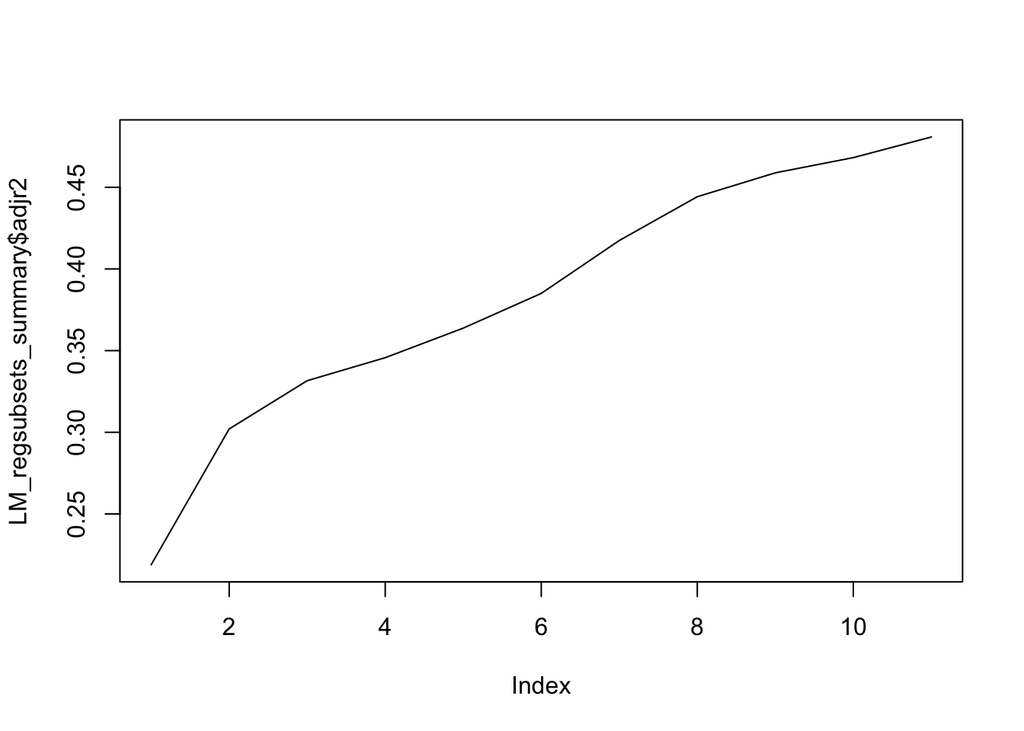

```r
plot(LM_regsubsets_summary$adjr2, type = "l")
nr_predictors_adjr2 <- which.max(LM_regsubsets_summary$adjr2)
points(nr_predictors_adjr2, LM_regsubsets_summary$adjR2[nr_predictors_adjr2], col = "red", cex = 2, pch = 20)
```

That is, the model suggests 11 predictors to be included.

Let’s look at $BIC$.

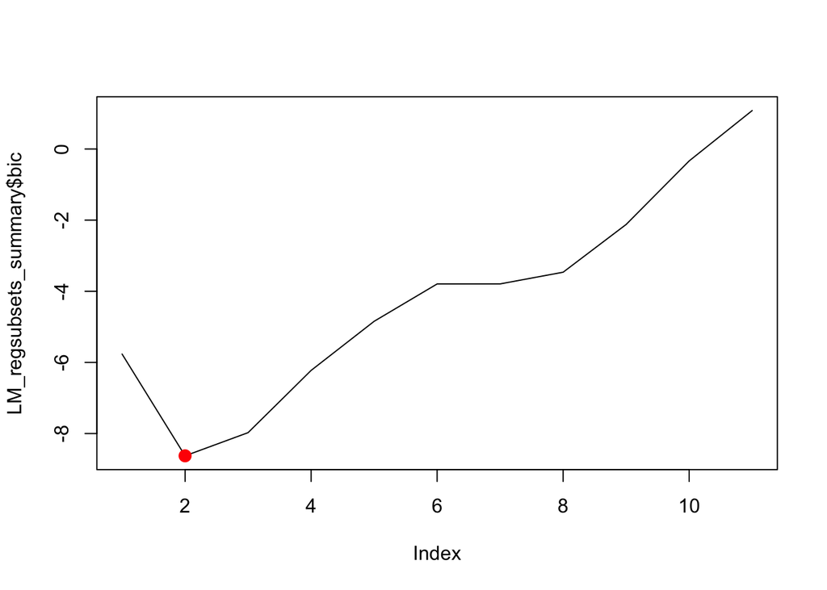

```r
plot(LM_regsubsets_summary$bic, type = "l")
nr_predictors_bic <- which.min(LM_regsubsets_summary$bic)
points(nr_predictors_bic, LM_regsubsets_summary$bic[nr_predictors_bic], col = "red", cex = 2, pch = 20)
```

That is, the model suggests 2 predictors to be included.

$BIC$ is more strict in terms of allowing predictors to enter the model. So let’s look finally to $C_p$:

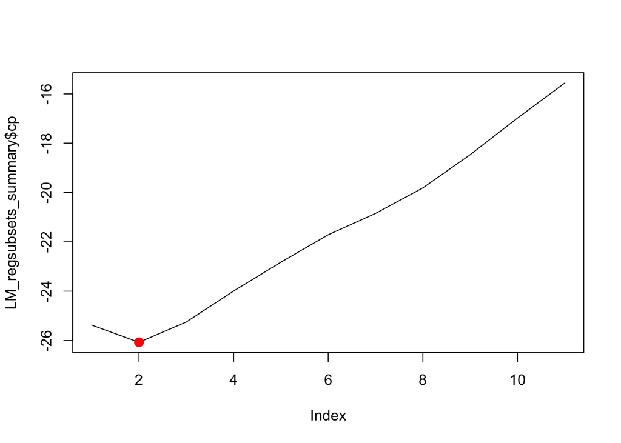

```r
plot(LM_regsubsets_summary$cp, type = "l")
nr_predictors_cp <- which.min(LM_regsubsets_summary$cp)
points(nr_predictors_cp, LM_regsubsets_summary$cp[nr_predictors_cp], col = "red", cex = 2, pch = 20)
```

Ok, so let’s stick to 11 predictors. These are:

```r
coef(LM_regsubsets, nr_predictors_adjr2)[-1]
```

```
##         ChOCI_R_P_sumimp_PRE               FAS_PR_sum_PRE
##                    0.2836217                   -0.0340362
##               TourettesTics1                        ADHD1
##                   -8.1696576                    5.0635709
##                     sexgirl1                     OCDonset
##                    1.3934541                   -0.6232885
##                 yearswithOCD              medicationSSRI1
##                    0.1336101                   -2.5504904
## treatm_expCAMHS.councelling1                    CGI_S_pre
##                   -1.4721644                    1.6578602
##                    checking1
##                    0.6074650
```

```r
best_preds <- names(coef(LM_regsubsets, nr_predictors_adjr2))[-1]  # first is "intercept"
```

Run model with best predictor subset to get all typical statistics.

```r
# best_preds <- str_replace(best_preds,"\\d","")
# model.matrix puts factor levels into names, that can cause confusion

train_mm <- data.frame(train_mm)

train_mm %>%
  dplyr::select(one_of(best_preds)) %>%
  do(tidy(lm(train_sample$CYBOCS_3m ~ ., data = .))) -> LM_regsubsets_bestsub

LM_regsubsets_bestsub %>%
  filter(term != "(Intercept)") %>%
  dplyr::select(term, statistic) %>%
  dplyr::rename(name = term, value = statistic) %>%
  mutate(rank = min_rank(desc(value))) -> regr_varimp$LM_regsubsets_bestsub
```

### 3.7.1 Predict values

Now let’s see the predictive accuracy using the TEST sample.

```r
predict.regsubsets = function(object, newdata, id, ...) {
        form  <-  as.formula(~.)
        mat  <-  model.matrix(form, newdata)
        coefi  <-  coef(object, id)
        xvars  <-  names(coefi)
        mat[, xvars] %*% coefi
}  # credit to: https://github.com/yufree/democode/blob/master/rml/predict.regsubsets.R

LM_regsubsets_predict <- predict(LM_regsubsets, newdata = test_sample, id = nr_predictors_adjr2)
# str(dummy_model2)
summary(LM_regsubsets_predict)
```

```
##        V1
##  Min.   :11.29
##  1st Qu.:13.66
##  Median :14.58
##  Mean   :14.40
##  3rd Qu.:15.04
##  Max.   :17.04
```

```r
R_2_LM_regsubsets <- R_2(LM_regsubsets_predict, test_sample$CYBOCS_3m)
RMSE_LM_regsubsets <- RMSE(LM_regsubsets_predict, test_sample$CYBOCS_3m)
```

Here, the $R^2$ is 0; the RMSE is 5.41.

# 4 Comparison of model results

```r
regr_results <- tibble(
   name_models = c("Lasso_1", "Lasso_2", "RF", "SVM", "GBM", "LM_uni", "LM_regsubsets"),
  RMSE_models = c(lasso_regr_1$RMSE, lasso_regr_2$RMSE, rf1_RMSE_test, svm1_RMSE_test, gbm1_RMSE_test, RMSE_lm_uni_Model2, RMSE_LM_regsubsets),
  R_2_models = c(lasso_regr_1$R_2, lasso_regr_2$R_2, rf1_R_2_test, svm1_R_2_test, gbm1_R_2_test, R_2_lm1, R_2_LM_regsubsets)
)

regr_results %>%
  dplyr::select(name_models, R_2_models, RMSE_models) %>%
  dplyr::rename(`model` = name_models, `Rsquared` = R_2_models, RMSE = RMSE_models) %>%
  mutate_if(is.numeric, round, digits = 2) %>%
  arrange(desc(Rsquared)) -> regr_results

regr_results %>%
  kable
```

| model | Rsquared | RMSE |
| --- | --- | --- |
| RF | 0.21 | 4.82 |
| Lasso_1 | 0.15 | 4.99 |
| LM_uni | 0.14 | 5.03 |
| GBM | 0.11 | 5.11 |
| SVM | 0.05 | 5.30 |
| LM_regsubsets | 0.00 | 5.41 |
| Lasso_2 | -0.81 | 8.36 |

Best model is: RF. And its important predictors are:

```r
print(rf1_varimp)
```

```
## rf variable importance
##
##   only 20 most important variables shown (out of 44)
##
##                               Overall
## yearswithOCD                  8.47664
## EWSASP_sum_PRE                6.37728
## CDI_S_sum_PRE                 5.35847
## OCD_treatm_expnone1           5.32118
## OCDonset                      3.83753
## CBT_OCD1                      2.93194
## CYBOCS_pre_COMP               2.67256
## CGI_S_pre                     2.53424
## sexgirl1                      2.42373
## EWSASC_sum_PRE                2.40981
## ChOCI_R_P_sumimp_PRE          1.55676
## CYBOCS_pre_OBS                1.55090
## treatm_expnone1               1.13391
## age                           1.11422
## ADHD1                         1.03981
## treatm_expCAMHS.councelling1  0.99418
## SocialPhob1                   0.98576
## symmetry1                     0.85248
## Education_parentOther1        0.74189
## Education_parentHigh.school1 -0.06755
```

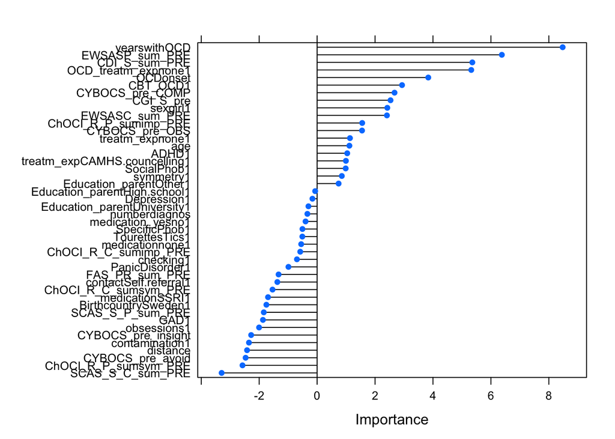

```r
plot(rf1_varimp)
```

After the first 5 predictors the curve appears to flatten down (like a “scree”). Following this reasoning, let’s extract the 5 most important predictors.

# 5 Evaluating variable importance

## 5.1 Variable importance for regression models

Finally, let’s combine all model results to derive the importance of variables after having fitted all these models.

Put the list elements with the var.imp. data in one data frame:

```r
do.call("rbind", regr_varimp) %>%
  rownames_to_column %>%
  dplyr::rename(model = rowname) %>%
  filter(name != "(Intercept)") %>%
  arrange(desc(value)) -> varimp_all


kable(varimp_all)
```

| model | name | value | rank |
| --- | --- | --- | --- |
| gbm_1.11 | ChOCI_R_P_sumimp_PRE | 1281.2108842 | 1 |
| gbm_1.30 | yearswithOCD | 1213.2091536 | 2 |
| gbm_1.29 | OCDonset | 834.6432174 | 3 |
| gbm_1.2 | CYBOCS_pre_COMP | 710.1921596 | 4 |
| gbm_1.7 | EWSASC_sum_PRE | 422.7780195 | 5 |
| gbm_1.8 | SCAS_S_C_sum_PRE | 291.4722955 | 6 |
| gbm_1.14 | SCAS_S_P_sum_PRE | 271.5466517 | 7 |
| gbm_1.37 | treatm_expnone1 | 265.3054804 | 8 |
| gbm_1.39 | CGI_S_pre | 213.2195771 | 9 |
| gbm_1.4 | CYBOCS_pre_avoid | 208.3671094 | 10 |
| gbm_1.28 | Education_parentUniversity1 | 201.7357160 | 11 |
| gbm_1.1 | CYBOCS_pre_OBS | 184.8534799 | 12 |
| gbm_1.36 | treatm_expCAMHS.councelling1 | 175.6633387 | 13 |
| gbm_1.23 | sexgirl1 | 139.3214939 | 14 |
| gbm_1.22 | numberdiagnos | 99.3487272 | 15 |
| gbm_1.3 | CYBOCS_pre_insight | 92.8314342 | 16 |
| gbm_1.40 | checking1 | 89.7274517 | 17 |
| gbm_1.24 | age | 77.2725664 | 18 |
| gbm_1.41 | obsessions1 | 72.4309432 | 19 |
| gbm_1.32 | distance | 42.3142966 | 20 |
| gbm_1.9 | CDI_S_sum_PRE | 39.0293153 | 21 |
| rf_1.30 | yearswithOCD | 8.4766360 | 1 |
| lasso_regr_2.6 | ADHD1 | 6.7379478 | 1 |
| rf_1.13 | EWSASP_sum_PRE | 6.3772750 | 2 |
| rf_1.9 | CDI_S_sum_PRE | 5.3584652 | 3 |
| rf_1.38 | OCD_treatm_expnone1 | 5.3211759 | 4 |
| lasso_regr_2.2 | Depression1 | 4.5705116 | 2 |
| rf_1.29 | OCDonset | 3.8375306 | 5 |
| rf_1.44 | CBT_OCD1 | 2.9319388 | 6 |
| rf_1.2 | CYBOCS_pre_COMP | 2.6725627 | 7 |

[output cut: 134 more lines]

```r
# varimp_all %>% filter(str_detect(model, "LM"))
```

Let’s pick the three most successful models, and let’s only consider the variables from those models.

```r
best_regr_models <- vector()

best_regr_models[1] <- regr_results$model[1]
best_regr_models[2] <- regr_results$model[2]
best_regr_models[3] <- regr_results$model[3]
```

So the best three models were RF, Lasso_1, LM_uni.

Now let’s look at the variable importance measures from these models

```r
varimp_best <- list()

varimp_all %>%
  mutate(model = tolower(model)) %>%
  filter(str_detect(model, tolower(regr_results$model[1]))) %>%
  top_n(-10) -> varimp_best[[1]]

kable(varimp_best[[1]])
```

| model | name | value | rank |
| --- | --- | --- | --- |
| rf_1.30 | yearswithOCD | 8.476636 | 1 |
| rf_1.13 | EWSASP_sum_PRE | 6.377275 | 2 |
| rf_1.9 | CDI_S_sum_PRE | 5.358465 | 3 |
| rf_1.38 | OCD_treatm_expnone1 | 5.321176 | 4 |
| rf_1.29 | OCDonset | 3.837531 | 5 |
| rf_1.44 | CBT_OCD1 | 2.931939 | 6 |
| rf_1.2 | CYBOCS_pre_COMP | 2.672563 | 7 |
| rf_1.39 | CGI_S_pre | 2.534242 | 8 |
| rf_1.23 | sexgirl1 | 2.423728 | 9 |
| rf_1.7 | EWSASC_sum_PRE | 2.409806 | 10 |

```r
# in string "lasso_1" kick out all non characters, and keep only characters, e., "alpha"
varimp_all %>%
  mutate(model = tolower(model)) %>%
  filter(str_detect(model, tolower(str_extract(regr_results$model[2], "[:alpha:]*")))) %>%
  top_n(-10) -> varimp_best[[2]]


kable(varimp_best[[2]])
```

| model | name | value | rank |
| --- | --- | --- | --- |
| lasso_regr_2.6 | ADHD1 | 6.7379478 | 1 |
| lasso_regr_2.2 | Depression1 | 4.5705116 | 2 |
| lasso_regr_2.8 | yearswithOCD | 1.6764487 | 3 |
| lasso_regr_1.4 | ADHD1 | 1.2139393 | 1 |
| lasso_regr_2.13 | checking1 | 1.0012487 | 4 |
| lasso_regr_1.7 | CGI_S_pre | 0.5534702 | 2 |
| lasso_regr_2.1 | ChOCI_R_P_sumimp_PRE | 0.2893093 | 5 |
| lasso_regr_1.5 | yearswithOCD | 0.2711508 | 3 |
| lasso_regr_1.2 | ChOCI_R_P_sumimp_PRE | 0.0698248 | 4 |
| lasso_regr_1.3 | SCAS_S_P_sum_PRE | 0.0536191 | 5 |

```r
varimp_all %>%
  mutate(model = tolower(model)) %>%
  filter(str_detect(model, tolower(str_extract(regr_results$model[3], "[:alpha:]*")))) %>%
  top_n(-10) -> varimp_best[[3]]


kable(varimp_best[[3]])
```

| model | name | value | rank |
| --- | --- | --- | --- |
| lm_regsubsets_bestsub.1 | ChOCI_R_P_sumimp_PRE | 2.0065527 | 1 |
| lm_regsubsets_bestsub.4 | ADHD1 | 1.8249432 | 2 |
| lm_regsubsets_bestsub.10 | CGI_S_pre | 1.1219252 | 3 |
| lm_regsubsets_bestsub.5 | sexgirl1 | 0.7615775 | 4 |
| lm_regsubsets_bestsub.11 | checking1 | 0.3428776 | 5 |
| lm_regsubsets_bestsub.7 | yearswithOCD | 0.2369959 | 6 |
| lm_regsubsets_bestsub.2 | FAS_PR_sum_PRE | -0.3128880 | 7 |
| lm_regsubsets_bestsub.9 | treatm_expCAMHS.councelling1 | -0.7839423 | 8 |
| lm_regsubsets_bestsub.8 | medicationSSRI1 | -1.0127796 | 9 |
| lm_regsubsets_bestsub.6 | OCDonset | -1.1663305 | 10 |

## 5.2 Hitlist of predictors

Let’s see which predictors are how frequent.

```r
varimp_top <- do.call(rbind.data.frame, varimp_best)


varimp_top$name %>%
  table %>%
   sort(decreasing = TRUE) %>%
   tibble(predictor = names(.), freq = as.vector(.)) -> varimp_top_of_top


kable(varimp_top_of_top)
```

| . | predictor | freq |
| --- | --- | --- |
| 4 | yearswithOCD | 4 |
| 3 | ADHD1 | 3 |
| 3 | CGI_S_pre | 3 |
| 3 | ChOCI_R_P_sumimp_PRE | 3 |
| 2 | checking1 | 2 |
| 2 | OCDonset | 2 |
| 2 | sexgirl1 | 2 |
| 1 | CBT_OCD1 | 1 |
| 1 | CDI_S_sum_PRE | 1 |
| 1 | CYBOCS_pre_COMP | 1 |
| 1 | Depression1 | 1 |
| 1 | EWSASC_sum_PRE | 1 |
| 1 | EWSASP_sum_PRE | 1 |
| 1 | FAS_PR_sum_PRE | 1 |
| 1 | medicationSSRI1 | 1 |
| 1 | OCD_treatm_expnone1 | 1 |
| 1 | SCAS_S_P_sum_PRE | 1 |
| 1 | treatm_expCAMHS.councelling1 | 1 |

[figure not shown]

```r
lab_list <- c("Duration of OCD",
"ChOCI-R-P impairment",
"ADHD",
"CGI-S",
"SCAS-S-P",
"Depression",
"Checking & obsessive hoarding",
"Sex: female",
"OCD onset",
"Previous treatment for OCD",
"EWSAS-P",
"EWSAS-C",
"CY-BOCS Compulsions subscale",
"CDI-S",
"Previous CBT for OCD"
)

varimp_top_of_top %>%
  ggplot(aes(x = reorder(predictor, freq), y = freq)) +
  geom_bar(stat="identity") +
  coord_flip() +
  xlab("predictor") +
  ylab("frequency") +
  labs(caption = "numeric outcome") +
  scale_x_discrete(labels = lab_list)
```

These are the variable that where among the 10 most important predictors in the three (best performing) models. Let’s take them as our “best guess” as the most important ones.

## 5.3 Variable importance intersection of both regression and classification models

Finally, let’s compare which predictors were deemd importance in *both* the regression and the classification models.

```r
load("data_objects/important_predictors.Rda")
load("data_objects/important_predictors_overview.Rda")


varimp_class_and_regr <- full_join(important_predictors_overview, varimp_top_of_top, by = "predictor")

varimp_class_and_regr %>%
  dplyr::select(predictor, freq.x, freq.y) %>%
  mutate_each(funs(ifelse(is.na(.), 0, .))) %>%
  mutate(freq_total = freq.x + freq.y) %>%
  dplyr::rename(classific_importance = freq.x, regression_importance = freq.y, importance_total = freq_total) %>%
  arrange(-importance_total) -> varimp_class_and_regr


varimp_class_and_regr %>%
   kable
```

| predictor | classific_importance | regression_importance | importance_total |
| --- | --- | --- | --- |
| yearswithOCD | 3 | 4 | 7 |
| OCDonset | 3 | 2 | 5 |
| CGI_S_pre | 1 | 3 | 4 |
| Education_parentUniversity1 | 3 | 0 | 3 |
| EWSASC_sum_PRE | 2 | 1 | 3 |
| ADHD1 | 0 | 3 | 3 |
| ChOCI_R_P_sumimp_PRE | 0 | 3 | 3 |
| ChOCI_R_C_sumsym_PRE | 2 | 0 | 2 |
| ChOCI_R_P_sumsym_PRE | 2 | 0 | 2 |
| CYBOCS_pre_avoid | 2 | 0 | 2 |
| obsessions1 | 2 | 0 | 2 |
| CDI_S_sum_PRE | 1 | 1 | 2 |
| EWSASP_sum_PRE | 1 | 1 | 2 |
| OCD_treatm_expnone1 | 1 | 1 | 2 |
| SCAS_S_P_sum_PRE | 1 | 1 | 2 |
| checking1 | 0 | 2 | 2 |
| sexgirl1 | 0 | 2 | 2 |
| BirthcountrySweden1 | 1 | 0 | 1 |
| contactSelf.referral1 | 1 | 0 | 1 |
| distance | 1 | 0 | 1 |
| CBT_OCD1 | 0 | 1 | 1 |
| CYBOCS_pre_COMP | 0 | 1 | 1 |
| Depression1 | 0 | 1 | 1 |
| FAS_PR_sum_PRE | 0 | 1 | 1 |
| medicationSSRI1 | 0 | 1 | 1 |
| treatm_expCAMHS.councelling1 | 0 | 1 | 1 |

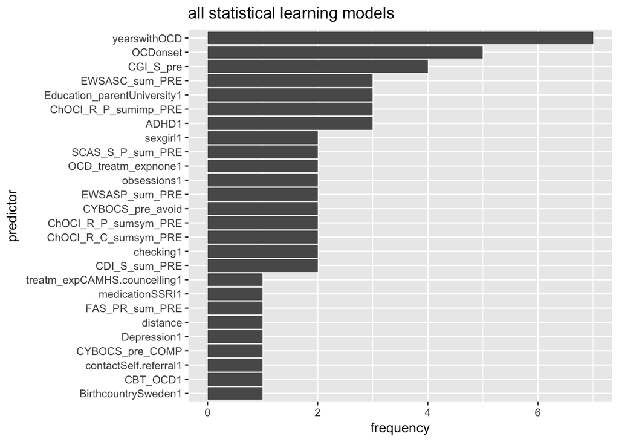

```r
varimp_class_and_regr %>%
  ggplot(aes(x = reorder(predictor, importance_total), y = importance_total)) +
  geom_bar(stat="identity") +
  coord_flip() +
  xlab("predictor") +
  ylab("frequency") +
  ggtitle("all statistical learning models")
```

In sum, the number of relevant predictors was 26 (totailing classification and regression).